# Trial Analysis

## Introduction

This vignette picks up where the previous one (Trial Definition), ends. To recap, our trial defines the six fundamental elements of a CRM trial as

#### The dose grid

The trial will use a dose grid consisting of the following doses: 1, 3, 9, 20, 30, 45, 60, 80 and 100. The units in which doses are defined is irrelevant to the operation of the CRM.

#### The dose-toxicity model

The trial uses a logistic log Normal dose toxicity model

$$log(\frac{p_i}{1 - p_i}) = \alpha +
\beta log(d_i / d^*)$$

where the prior joint distribution of $\alpha$ and $\beta$ is

$$\begin{bmatrix}
\alpha \\
log(\beta)
\end{bmatrix} \sim
N\begin{pmatrix}
\begin{bmatrix}
-0.85\\0
\end{bmatrix} ,
\begin{bmatrix}
1 & -0.5 \\
-0.5 & 1
\end{bmatrix}
\end{pmatrix}.$$

#### The increment rule

Note that a 2-fold *increment* corresponds to a 3-fold *escalation*.

#### The dose selection rule

Here, we choose to use Neuenschwander’s rule (Neuenschwander et al. 2008), in which the dose for the next cohort to be the dose (amongst those doses that are eligible for selection according to the escalation rule) that has the highest posterior chance of having a probability of toxicity in the target range - here [0.2, 0.35) - provided that the dose’s chance of having a probability in the overdose range - here [0.35, 1.0] - is less than 0.25.

#### The cohort size

Whilst the dose for the next cohort is 20 or less *and* no DLTs have been observed, the minimum cohort size is 1. Otherwise, it is 3.

#### The stopping rule

The trial will stop when *either*

- Twenty patients have been recruited, or.
- Both of the following conditions are true
  - At least three cohorts must have been treated AND
  - The probability that the current estimate of the MTD is in the target toxicity range must be at least 0.5.

#### Trial definition

The code to define these elements of the trial design is given in the Trial Definition vignette.

## Analysing a trial

Given the trial design constructed above, the process of analysing a real life instance of the trial is simply a matter of providing the model with the actual toxicity status of the participants treated so far. The escalation rules we defined earlier allow the use of a single patient run-in until either the first DLT is observed or until dose 20 has been administered.

### The single patient run-in

Assume that the first three patients - dosed at `1`, `3`, and `9` - completed the trial without incident, but that the fourth patient - treated at `20` - experienced a DLT.

We provide this information to `crmPack` via a `Data` object:

```r
firstFour <- Data(
  x = c(1, 3, 9, 20),
  y = c(0, 0, 0, 1),
  ID = 1:4,
  cohort = 1:4,
  doseGrid = doseGrid
)
```

Within a `Data` object, the doses at which each patient is treated are given by the `x` slot and their toxicity status (a Boolean where a toxicity is represented by a truthy value) by the `y` slot.

The observed data is easily visualised

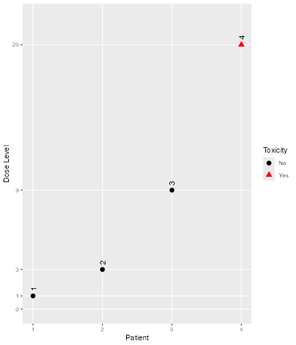

```r
plot(firstFour)
```

and, since the `plot` method returns a `ggplot` object, it is easily customised.

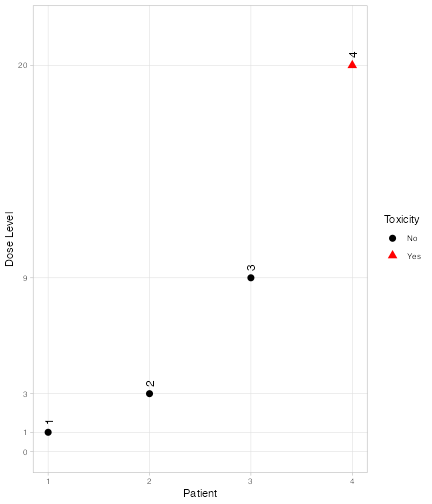

```r
plot(firstFour) + theme_light()
```

We first define the MCMC options, explicitly setting a seed and the kind for the random number generator, in order to make sure that the results are reproducible:

```r
vignetteMcmcOptions <- McmcOptions(
  burnin = 100,
  step = 2,
  samples = 1000,
  rng_seed = 321,
  rng_kind = "Wichmann-Hill"
)
```

Note that in practice one would use larger numbers for `burnin` and `samples` than those used here for the sake of saving computation time on the CRAN checks.

Now, we can update the model to obtain the posterior estimate of the dose-toxicity curve:

```r
postSamples <- mcmc(
  data = firstFour,
  model = model,
  options = vignetteMcmcOptions
)
```

The posterior estimate of the dose toxicity curve is easily visualised:

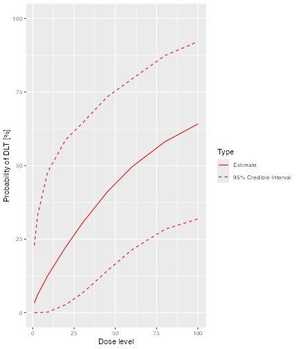

```r
plot(postSamples, model, firstFour)
```

A visual representation of the model’s state is obtained with:

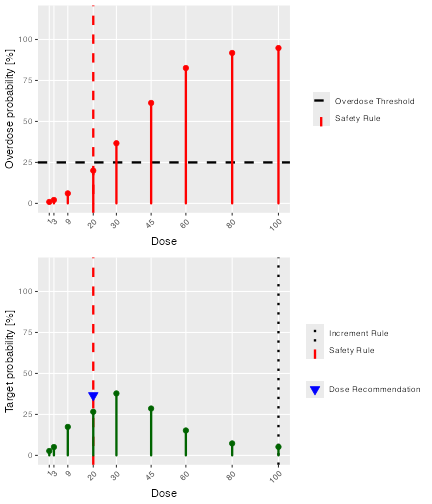

```r
nextBest(
  my_next_best,
  doselimit = 100,
  samples = postSamples,
  model = model,
  data = empty_data
)$plot
```

We can produce a tabulation of the model state with

```r
tabulatePosterior <- function(mcmcSamples, observedData) {
  as_tibble(
    nextBest(
      my_next_best,
      doselimit = 100,
      samples = mcmcSamples,
      model = model,
      data = observedData
    )$probs
  ) %>%
    left_join(
      tibble(
        dose = observedData@x,
        WithDLT = observedData@y
      ) %>%
        group_by(dose) %>%
        summarise(
          Treated = n(),
          WithDLT = sum(WithDLT),
          .groups = "drop"
        ),
      by = "dose"
    ) %>%
    replace_na(list(Treated = 0, WithDLT = 0)) %>%
    select(dose, Treated, WithDLT, target, overdose) %>%
    kableExtra::kable(
      col.names = c("Dose", "Treated", "With DLT", "Target range", "Overdose range"),
      digits = c(0, 0, 0, 3, 3)
    ) %>%
    kableExtra::add_header_above(c(" " = 1, "Participants" = 2, "Probability that dose is in " = 2))
}

tabulatePosterior(postSamples, firstFour)
```

| Dose | Participants Treated | Participants With DLT | Probability that dose is in Target range | Probability that dose is in Overdose range |
| --- | --- | --- | --- | --- |
| 1 | 1 | 0 | 0.027 | 0.009 |
| 3 | 1 | 0 | 0.051 | 0.021 |
| 9 | 1 | 0 | 0.174 | 0.061 |
| 20 | 1 | 1 | 0.266 | 0.200 |
| 30 | 0 | 0 | 0.378 | 0.367 |
| 45 | 0 | 0 | 0.286 | 0.613 |
| 60 | 0 | 0 | 0.152 | 0.826 |
| 80 | 0 | 0 | 0.073 | 0.918 |
| 100 | 0 | 0 | 0.052 | 0.948 |

From these presentations, we can see that:

1. The highest dose so far administered is `20`, so the escalation rule permits doses up to and including `40` to be considered as the dose for the next cohort. However…
2. Doses of `30` and above are considered unsafe
3. Of the remaining doses, `20` has the highest posterior probability of being in the target toxicity range
4. A DLT has been reported

Items 1 and 4 in the list tell us both that the size of the next cohort should be three. Items 2 and 3 together imply that the highest dose that can be used in the next cohort is `20`.

```r
nextMaxDose <- maxDose(my_increments, firstFour)
nextMaxDose
```

```
#> [1] 40
```

```r
doseRecommendation <- nextBest(
  my_next_best,
  doselimit = nextMaxDose,
  samples = postSamples,
  model = model,
  data = firstFour
)
doseRecommendation$value
```

```
#> [1] 20
```

Thus, the model’s recommendation is that the next cohort should consist of three patients, each treated at `20`.

However, given that the probability that `20` is in the overdose range is only just less than the threshold of 0.25 (and because the only participant so far treated at `20` experienced a DLT) it would be a perfectly reasonable clinical decision to treat the next cohort at `10` - or, indeed, at any other dose below `20`. *There is absolutely no obligation to follow the CRM dose recommendation without consideration of other factors that might affect the choice of the most appropriate dose for the next cohort.* However, for the purpose of exposition, we will treat the next cohort at `20`, as recommended by the model.

We can confirm that the trial’s stopping rules have not been satisfied:

```r
stopTrial(
  my_stopping,
  dose = doseRecommendation$value,
  postSamples,
  model,
  firstFour
)
```

```
#> [1] FALSE
#> attr(,"message")
#> attr(,"message")[[1]]
#> attr(,"message")[[1]][[1]]
#> [1] "Number of cohorts is 4 and thus reached the prespecified minimum number 3"
#>
#> attr(,"message")[[1]][[2]]
#> [1] "Probability for target toxicity is 27 % for dose 20 and thus below the required 50 %"
#>
#>
#> attr(,"message")[[2]]
#> [1] "Number of patients is 4 and thus below the prespecified minimum number 20"
#>
#> attr(,"individual")
#> attr(,"individual")[[1]]
#> [1] FALSE
#> attr(,"message")
#> attr(,"message")[[1]]
#> [1] "Number of cohorts is 4 and thus reached the prespecified minimum number 3"
#>
#> attr(,"message")[[2]]
#> [1] "Probability for target toxicity is 27 % for dose 20 and thus below the required 50 %"
#>
#> attr(,"individual")
#> attr(,"individual")[[1]]
#> [1] TRUE
#> attr(,"message")
#> [1] "Number of cohorts is 4 and thus reached the prespecified minimum number 3"
#> attr(,"report_label")
#> [1] "≥ 3 cohorts dosed"
#>
#> attr(,"individual")[[2]]
#> [1] FALSE
#> attr(,"message")
#> [1] "Probability for target toxicity is 27 % for dose 20 and thus below the required 50 %"
#> attr(,"report_label")
#> [1] "P(0.2 ≤ prob(DLE | NBD) ≤ 0.35) ≥ 0.5"
#>
#> attr(,"report_label")
#> [1] NA
#>
#> attr(,"individual")[[2]]
#> [1] FALSE
#> attr(,"message")
#> [1] "Number of patients is 4 and thus below the prespecified minimum number 20"
#> attr(,"report_label")
#> [1] "≥ 20 patients dosed"
#>
#> attr(,"report_label")
#> [1] NA
```

### The first full cohort

Assume that none of the three patients in the first full cohort report a DLT:

```r
firstFullCohort <- Data(
  x = c(1, 3, 9, 20, 20, 20, 20),
  y = c(0, 0, 0, 1, 0, 0, 0),
  ID = 1:7,
  cohort = c(1:4, rep(5, 3)),
  doseGrid = doseGrid
)
```

Update the model:

```r
postSamples1 <- mcmc(
  data = firstFullCohort,
  model = model,
  options = vignetteMcmcOptions
)
```

Tabulate the posterior:

```r
tabulatePosterior(postSamples1, firstFullCohort)
```

| Dose | Participants Treated | Participants With DLT | Probability that dose is in Target range | Probability that dose is in Overdose range |
| --- | --- | --- | --- | --- |
| 1 | 1 | 0 | 0.006 | 0.000 |
| 3 | 1 | 0 | 0.021 | 0.000 |
| 9 | 1 | 0 | 0.079 | 0.016 |
| 20 | 4 | 1 | 0.196 | 0.064 |
| 30 | 0 | 0 | 0.371 | 0.175 |
| 45 | 0 | 0 | 0.411 | 0.457 |
| 60 | 0 | 0 | 0.259 | 0.700 |
| 80 | 0 | 0 | 0.102 | 0.892 |
| 100 | 0 | 0 | 0.061 | 0.935 |

Should the trial stop? If not, what dose should be used for the next cohort?

```r
nextMaxDose <- maxDose(my_increments, firstFullCohort)
nextMaxDose
```

```
#> [1] 40
```

```r
doseRecommendation <- nextBest(
  my_next_best,
  doselimit = nextMaxDose,
  samples = postSamples1,
  model = model,
  data = firstFullCohort
)
doseRecommendation$value
```

```
#> [1] 30
```

```r
x <- stopTrial(
  my_stopping,
  dose = doseRecommendation$value,
  postSamples1,
  model,
  firstFullCohort
)
attributes(x) <- NULL
x
```

```
#> [1] FALSE
```

So the trial should continue, treating three patients in the next cohort at `30`.

### The second full cohort

Assume that none of the three patients in the next cohort report a DLT:

```r
secondFullCohort <- Data(
  x = c(1, 3, 9, 20, 20, 20, 20, 30, 30, 30),
  y = c(0, 0, 0, 1, 0, 0, 0, 0, 0, 0),
  ID = 1:10,
  cohort = c(1:4, rep(5, 3), rep(6, 3)),
  doseGrid = doseGrid
)
```

Update the model:

```r
postSamples2 <- mcmc(
  data = secondFullCohort,
  model = model,
  options = vignetteMcmcOptions
)
```

Tabulate the posterior:

```r
tabulatePosterior(postSamples2, secondFullCohort)
```

| Dose | Participants Treated | Participants With DLT | Probability that dose is in Target range | Probability that dose is in Overdose range |
| --- | --- | --- | --- | --- |
| 1 | 1 | 0 | 0.003 | 0.000 |
| 3 | 1 | 0 | 0.008 | 0.000 |
| 9 | 1 | 0 | 0.026 | 0.003 |
| 20 | 4 | 1 | 0.106 | 0.018 |
| 30 | 3 | 0 | 0.243 | 0.060 |
| 45 | 0 | 0 | 0.434 | 0.249 |
| 60 | 0 | 0 | 0.374 | 0.534 |
| 80 | 0 | 0 | 0.185 | 0.784 |
| 100 | 0 | 0 | 0.108 | 0.877 |

The dose with the highest posterior probability of being in the target toxicity range is now `45`, but this dose almost has an unacceptably high probability of being in the overdose range. So the team decides to go for a next cohort at `30`:

```r
nextMaxDose <- maxDose(my_increments, secondFullCohort)
nextMaxDose
```

```
#> [1] 45
```

```r
doseRecommendation <- nextBest(
  my_next_best,
  doselimit = nextMaxDose,
  samples = postSamples2,
  model = model,
  data = secondFullCohort
)
doseRecommendation$value
```

```
#> [1] 45
```

```r
x <- stopTrial(
  my_stopping,
  dose = 30, # team decision.
  postSamples2,
  model,
  secondFullCohort
)
attributes(x) <- NULL
x
```

```
#> [1] FALSE
```

### The third full cohort

Assume that none of the three patients in the third cohort report a DLT:

```r
thirdFullCohort <- Data(
  x = c(1, 3, 9, rep(20, 4), rep(30, 6)),
  y = c(0, 0, 0, 1, rep(0, 9)),
  ID = 1:13,
  cohort = c(1:4, rep(5, 3), rep(6, 3), rep(7, 3)),
  doseGrid = doseGrid
)
```

Update the model:

```r
postSamples3 <- mcmc(
  data = thirdFullCohort,
  model = model,
  options = vignetteMcmcOptions
)
```

Tabulate the posterior:

```r
tabulatePosterior(postSamples3, thirdFullCohort)
```

| Dose | Participants Treated | Participants With DLT | Probability that dose is in Target range | Probability that dose is in Overdose range |
| --- | --- | --- | --- | --- |
| 1 | 1 | 0 | 0.000 | 0.000 |
| 3 | 1 | 0 | 0.003 | 0.000 |
| 9 | 1 | 0 | 0.005 | 0.000 |
| 20 | 4 | 1 | 0.052 | 0.005 |
| 30 | 6 | 0 | 0.163 | 0.018 |
| 45 | 0 | 0 | 0.457 | 0.132 |
| 60 | 0 | 0 | 0.388 | 0.459 |
| 80 | 0 | 0 | 0.219 | 0.722 |
| 100 | 0 | 0 | 0.138 | 0.825 |

`45` is still the dose with the highest posterior probability of being in the target toxicity range, and its probability of being in the overdose range is now acceptable. Therefore, the trial should continue and the next cohort should be treated at `45`:

```r
nextMaxDose <- maxDose(my_increments, thirdFullCohort)
nextMaxDose
```

```
#> [1] 45
```

```r
doseRecommendation <- nextBest(
  my_next_best,
  doselimit = nextMaxDose,
  samples = postSamples3,
  model = model,
  data = thirdFullCohort
)
doseRecommendation$value
```

```
#> [1] 45
```

```r
x <- stopTrial(
  my_stopping,
  dose = doseRecommendation$value,
  postSamples3,
  model,
  thirdFullCohort
)
attributes(x) <- NULL
x
```

```
#> [1] FALSE
```

### The fourth full cohort

Assume that none of the three patients in the fourth cohort report a DLT:

```r
fourthFullCohort <- Data(
  x = c(1, 3, 9, rep(20, 4), rep(30, 6), rep(45, 3)),
  y = c(0, 0, 0, 1, rep(0, 12)),
  ID = 1:16,
  cohort = c(1:4, rep(5:8, each = 3)),
  doseGrid = doseGrid
)
```

Update the model:

```r
postSamples4 <- mcmc(
  data = fourthFullCohort,
  model = model,
  options = vignetteMcmcOptions
)
```

Tabulate the posterior:

```r
tabulatePosterior(postSamples4, fourthFullCohort)
```

| Dose | Participants Treated | Participants With DLT | Probability that dose is in Target range | Probability that dose is in Overdose range |
| --- | --- | --- | --- | --- |
| 1 | 1 | 0 | 0.000 | 0.000 |
| 3 | 1 | 0 | 0.000 | 0.000 |
| 9 | 1 | 0 | 0.004 | 0.000 |
| 20 | 4 | 1 | 0.026 | 0.000 |
| 30 | 6 | 0 | 0.088 | 0.013 |
| 45 | 3 | 0 | 0.337 | 0.084 |
| 60 | 0 | 0 | 0.375 | 0.371 |
| 80 | 0 | 0 | 0.263 | 0.639 |
| 100 | 0 | 0 | 0.224 | 0.740 |

`60` is now the dose with the highest posterior probability of being in the target toxicity range, but its probability of being in the overdose range is unacceptable. Therefore, the trial should continue and the next cohort should be treated at `45`:

```r
nextMaxDose <- maxDose(my_increments, fourthFullCohort)
nextMaxDose
```

```
#> [1] 67.5
```

```r
doseRecommendation <- nextBest(
  my_next_best,
  doselimit = nextMaxDose,
  samples = postSamples4,
  model = model,
  data = fourthFullCohort
)
doseRecommendation$value
```

```
#> [1] 45
```

```r
x <- stopTrial(
  my_stopping,
  dose = doseRecommendation$value,
  postSamples4,
  model,
  fourthFullCohort
)
attributes(x) <- NULL
x
```

```
#> [1] FALSE
```

### The fifth full cohort

```r
fifthFullCohort <- Data(
  x = c(1, 3, 9, rep(20, 4), rep(30, 6), rep(45, 6)),
  y = c(0, 0, 0, 1, rep(0, 13), 1, 1),
  ID = 1:19,
  cohort = c(1:4, rep(5:9, each = 3)),
  doseGrid = doseGrid
)
```

Update the model:

```r
postSamples5 <- mcmc(
  data = fifthFullCohort,
  model = model,
  options = vignetteMcmcOptions
)
```

Tabulate the posterior:

```r
tabulatePosterior(postSamples5, fifthFullCohort)
```

| Dose | Participants Treated | Participants With DLT | Probability that dose is in Target range | Probability that dose is in Overdose range |
| --- | --- | --- | --- | --- |
| 1 | 1 | 0 | 0.000 | 0.000 |
| 3 | 1 | 0 | 0.000 | 0.000 |
| 9 | 1 | 0 | 0.012 | 0.000 |
| 20 | 4 | 1 | 0.079 | 0.003 |
| 30 | 6 | 0 | 0.212 | 0.019 |
| 45 | 6 | 2 | 0.528 | 0.183 |
| 60 | 0 | 0 | 0.368 | 0.579 |
| 80 | 0 | 0 | 0.168 | 0.818 |
| 100 | 0 | 0 | 0.094 | 0.896 |

`45` remains the dose with the highest posterior probability of being in the target toxicity range, and its probability of being in the overdose range is acceptable. Moreover, the probability that `45` is in the target toxicity range is above 0.5 and more than three cohorts have been treated in total. Therefore, the trial should stop and conclude that `45` is the MTD:

```r
nextMaxDose <- maxDose(my_increments, fifthFullCohort)
nextMaxDose
```

```
#> [1] 67.5
```

```r
doseRecommendation <- nextBest(
  my_next_best,
  doselimit = nextMaxDose,
  samples = postSamples5,
  model = model,
  data = fifthFullCohort
)
doseRecommendation$value
```

```
#> [1] 45
```

```r
x <- stopTrial(
  my_stopping,
  dose = doseRecommendation$value,
  postSamples5,
  model,
  fifthFullCohort
)
x
```

```
#> [1] TRUE
#> attr(,"message")
#> attr(,"message")[[1]]
#> attr(,"message")[[1]][[1]]
#> [1] "Number of cohorts is 9 and thus reached the prespecified minimum number 3"
#>
#> attr(,"message")[[1]][[2]]
#> [1] "Probability for target toxicity is 53 % for dose 45 and thus above the required 50 %"
#>
#>
#> attr(,"message")[[2]]
#> [1] "Number of patients is 19 and thus below the prespecified minimum number 20"
#>
#> attr(,"individual")
#> attr(,"individual")[[1]]
#> [1] TRUE
#> attr(,"message")
#> attr(,"message")[[1]]
#> [1] "Number of cohorts is 9 and thus reached the prespecified minimum number 3"
#>
#> attr(,"message")[[2]]
#> [1] "Probability for target toxicity is 53 % for dose 45 and thus above the required 50 %"
#>
#> attr(,"individual")
#> attr(,"individual")[[1]]
#> [1] TRUE
#> attr(,"message")
#> [1] "Number of cohorts is 9 and thus reached the prespecified minimum number 3"
#> attr(,"report_label")
#> [1] "≥ 3 cohorts dosed"
#>
#> attr(,"individual")[[2]]
#> [1] TRUE
#> attr(,"message")
#> [1] "Probability for target toxicity is 53 % for dose 45 and thus above the required 50 %"
#> attr(,"report_label")
#> [1] "P(0.2 ≤ prob(DLE | NBD) ≤ 0.35) ≥ 0.5"
#>
#> attr(,"report_label")
#> [1] NA
#>
#> attr(,"individual")[[2]]
#> [1] FALSE
#> attr(,"message")
#> [1] "Number of patients is 19 and thus below the prespecified minimum number 20"
#> attr(,"report_label")
#> [1] "≥ 20 patients dosed"
#>
#> attr(,"report_label")
#> [1] NA
```

## Summarising the trial results

crmPack provides a wealth of information about the trial’s results. The following code snippets illustrate some of the many possibilities for how the trial might be summarised.

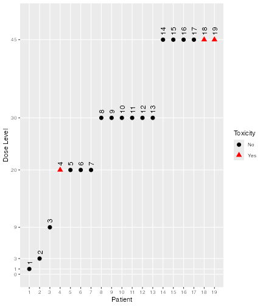

```r
plot(fifthFullCohort)
```

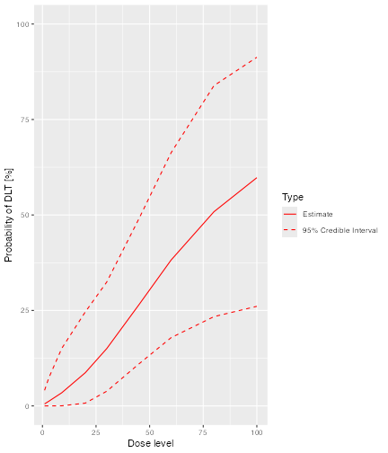

```r
plot(postSamples5, model, fifthFullCohort)
```

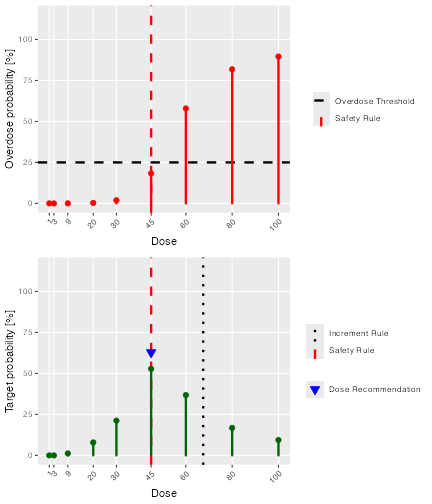

```r
doseRecommendation$plot
```

With a little bit of work, we can obtain a more detailed summary and plot of the posterior probabilities of toxicity at each dose:

```r
slotNames(model)
```

```
#> [1] "params"          "ref_dose"        "datamodel"       "priormodel"
#> [5] "modelspecs"      "init"            "datanames"       "datanames_prior"
#> [9] "sample"
```

```r
fullSamples <- tibble(
  Alpha = postSamples5@data$alpha0,
  Beta = postSamples5@data$alpha1
) %>%
  expand(nesting(Alpha, Beta), Dose = doseGrid) %>%
  rowwise() %>%
  mutate(P = probFunction(model, alpha0 = Alpha, alpha1 = Beta)(dose = Dose)) %>%
  ungroup()

fullSummary <- fullSamples %>%
  group_by(Dose) %>%
  summarise(
    Mean = mean(P),
    Median = median(P),
    Q = list(quantile(P, probs = c(0.05, 0.1, 0.25, 0.75, 0.9, 0.95), na.rm = TRUE))
  ) %>%
  unnest_wider(
    col = Q,
    names_repair = function(.x) {
      ifelse(
        str_detect(.x, "\\d+%"),
        sprintf("Q%02.0f", as.numeric(str_remove_all(.x, "%"))),
        .x
      )
    }
  )

fullSummary %>%
  kableExtra::kable(
    col.names = c("Dose", "Mean", "Median", "5th", "10th", "25th", "75th", "90th", "95th"),
    digits = c(0, rep(3, 8))
  ) %>%
  add_header_above(c(" " = 3, "Quantiles" = 6)) %>%
  add_header_above(c(" " = 1, "P(Toxicity)" = 8))
```

| Dose | P(Toxicity) Mean | P(Toxicity) Median | P(Toxicity) Quantiles 5th | P(Toxicity) Quantiles 10th | P(Toxicity) Quantiles 25th | P(Toxicity) Quantiles 75th | P(Toxicity) Quantiles 90th | P(Toxicity) Quantiles 95th |
| --- | --- | --- | --- | --- | --- | --- | --- | --- |
| 1 | 0.007 | 0.000 | 0.000 | 0.000 | 0.000 | 0.005 | 0.021 | 0.036 |
| 3 | 0.015 | 0.003 | 0.000 | 0.000 | 0.000 | 0.017 | 0.048 | 0.070 |
| 9 | 0.040 | 0.020 | 0.000 | 0.001 | 0.006 | 0.059 | 0.108 | 0.141 |
| 20 | 0.093 | 0.076 | 0.011 | 0.018 | 0.038 | 0.135 | 0.207 | 0.241 |
| 30 | 0.154 | 0.134 | 0.044 | 0.058 | 0.091 | 0.207 | 0.282 | 0.309 |
| 45 | 0.265 | 0.250 | 0.127 | 0.147 | 0.183 | 0.332 | 0.399 | 0.459 |
| 60 | 0.379 | 0.374 | 0.184 | 0.211 | 0.271 | 0.466 | 0.573 | 0.608 |
| 80 | 0.502 | 0.489 | 0.237 | 0.278 | 0.364 | 0.639 | 0.743 | 0.813 |
| 100 | 0.587 | 0.581 | 0.279 | 0.327 | 0.424 | 0.753 | 0.853 | 0.906 |

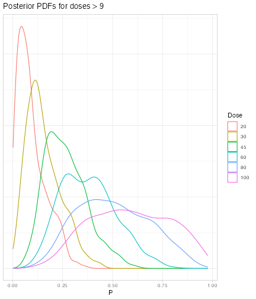

```r
fullSamples %>%
  filter(Dose > 9) %>%
  ggplot() +
  geom_density(aes(x = P, color = as.factor(Dose))) +
  theme_light() +
  theme(
    axis.text.y = element_blank(),
    axis.title.y = element_blank(),
    axis.ticks.y = element_blank()
  ) +
  labs(
    title = "Posterior PDFs for doses > 9",
    colour = "Dose"
  )
```

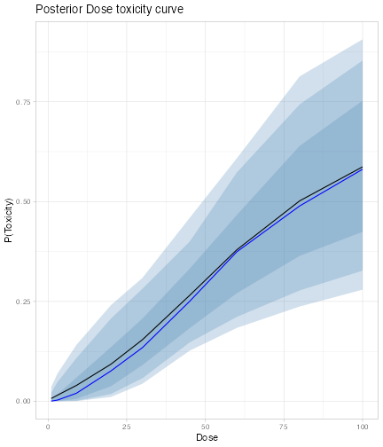

```r
fullSummary %>%
  ggplot(aes(x = Dose)) +
  geom_ribbon(aes(ymin = Q05, ymax = Q95), fill = "steelblue", alpha = 0.25) +
  geom_ribbon(aes(ymin = Q10, ymax = Q90), fill = "steelblue", alpha = 0.25) +
  geom_ribbon(aes(ymin = Q25, ymax = Q75), fill = "steelblue", alpha = 0.25) +
  geom_line(aes(y = Mean), colour = "black") +
  geom_line(aes(y = Median), colour = "blue") +
  theme_light() +
  labs(
    title = "Posterior Dose toxicity curve",
    colour = "Dose",
    y = "P(Toxicity)"
  )
```

## References

Neuenschwander, Beat, Michael Branson, and Thomas Gsponer. 2008. “Critical aspects of the Bayesian approach to phase I cancer trials.” *Statistics in Medicine* 27 (13): 2420–39. https://onlinelibrary.wiley.com/doi/10.1002/sim.3230.